1. Literature: what are n-grams, who used them
- assumption-free
- curse of dimensionality
2. Methods:
- QuiPT (Fisher exact test, indefinitely faster, multiple criteria)
- mention usage of the bit library for maximum computational speed
- slam package for sparse encoding of data, work with even very large data sets dealing with RAM constraints
- multiple criteria
- Compute how drastic must be the difference of fractions in both groups.
- Simulation study (motif length, sequence lenth, alphabet length) - sensitivity.
3. Results (what?)

## Methods

### Permutation test

Let us consider target $y=(y_1, ..., y_n)$ and matrix of features $X\in M_{n\times p}$. More specifically, as we focus on a method for filtering k-mer, we shall focus on one specific feature $x=(x_1, ...., x_n)$. When $x$ origins from positioned k-mer analysis then it is binary. In this paper we assume that $y$ is also binary.

$p_{value} \approx \frac{\sum_i^m C(s_i(x), s_i(y))>C(x,y)}{m}$ where m is number of permutations, and $s_i$ denotes shuffling in i-th permutation.

### Quick Permutation Test - QuiPT

In this secion we shall outline how one can avoid performing huge number of permutations and get exact p-values. The main idea of this approach was previously described in http://www.cytel.co/hs-fs/hub/1670/file-2600444346-pdf/lib/pubs/exact-inference-for-categorical-data.pdf and we shall briefly state what is that idea based on, and we show how we managed to speed it up.

Let us consider the contingency table for $y$ and $x$:

| target\feature | 1 | 0 |
| --- | --- | --- |
| 1 | $n_{1,1}$ | $n_{1,0}$ |
| 0 | $n_{0,1}$ | $n_{0,0}$ |

If probability that target equals 1 is $p$ and probability that feature equals 1 is $q$ and feature and target are independant then each of them has the following probabilities $P((Target, Feature) = (1,1)) = p \cdot q$ $P((Target, Feature) = (1,0)) = p \cdot (1-q)$ $P((Target, Feature) = (0,1)) = (1-p) \cdot q$ $P((Target, Feature) = (0,0)) = (1-p) \cdot (1-q)$

This means that a target-feature can be described as multinomial distribution.

${n \choose n_{1,1}} (p\cdot q)^{n_{1,1}} {n - n_{1,1} \choose n_{1,0}} (p\cdot (1-q))^{n_{1,0}} {n - n_{1,1} - n_{1,0} \choose n_{0,1}} ((1-p)\cdot q)^{n_{0,1}} {n - n_{1,1} - n_{1,0} -n_{0,1}\choose n_{0,0}} ((1-p)\cdot (1-q))^{n_{0,0}}$

with additional restriction that $n_{1,\cdot} = n_{1,1} + n_{1,0}$ and $n_{\cdot, 1} = n_{1,1} + n_{0,1}$ are known and fixed as they describe the number of ,,ones" for target and feature respectively.

The introduction of these restrictions is not an unnecessary complication, but in fact simplifies computations, because we can describe whole confusion matrix using only $n_{1,1}$.

Observe that $n_{1,1}$ is from range $[0,min(n_{\cdot, 1}, n_{1, \cdot})]$. So we get probability of certain contingency table as conditional distribution, as impose restrictions on two parameters $n_{, 1} $ and $n_{1, \cdot}$ We can compute IG for each possible value of $n_{1,1}$ and finally we get distribution of Information Gain under hypothesis that target and feature are independant.

Having exact distribution allows us to perform permutation test much quicker as we no longer need large number of replications. Furthermore, by using exact test we will get precise values of even in tails of statistic distribution, which was not guaranteed with random permutations. In fact, suppose we want to perform test with $\alpha=10^{-8}$, which is not uncommon value when we adjust for multiple testing - more on that later. Even for huge number of permuations $m=10^8$ standard deviation of permutation test estimate $\frac{p(1-p)}{m}$ is roughly equal true p-value itself.

In the context of k-mer data we can speed up our algorithm even further. Note that since target $y$ is common for testing all k-mer features, test statistics depends only on number of positive cases in feature $n_{\cdot, 1}$. Though we test millions of features, there are just few distributions that we need to compute, as usually number of positives in k-mer is small. We take advantage of this fact, and therefore complexity of our algorithm is roughly equal $n*p$.

Furthermore, as we deal with sparse vectors, our implementation in R is optimized by using libraries **bit**, which speeds up computing entropy and information gain, and **slam**, for sparse encoding of data. Thanks to those details **biogram** works with even very large data sets, being limited only by available RAM.

[output not shown]

Caption: Size of data set (a matrix with the number of records equal to the size) in the memory. matrix is a standard R matrix, while slam is the size of the object created using the slam package.

###### Relationship with Fisher’s exact test

In fact, QuiPT can give different results than Fisher’s exact test as implemented in R.

```r
library(biogram)
n11 <- 15
n10 <- 0
n01 <- 30
n00 <- 15

target_feature <- create_feature_target(n11 = n11, n01 = n01, n10 = n10, n00 = n00)
m <- matrix(c(n11,  n10,  n01,  n00), ncol = 2)
fisher.test(x = m, alternative = "t")
```

```
##
##  Fisher's Exact Test for Count Data
##
## data:  m
## p-value = 0.01281
## alternative hypothesis: true odds ratio is not equal to 1
## 95 percent confidence interval:
##  1.499432      Inf
## sample estimates:
## odds ratio
##        Inf
```

```r
test_features(target_feature[, 1], cbind(target_feature[, 2], target_feature[, 2]))
```

```
##    feature1    feature2
## 0.007322474 0.007322474
```

Where does the difference come from?

For $n_{11}=7$ we have higher probability of occurence (0.0054897) smaller than one for $n_{11}=15$ - 0.0064832, which means that Fisher’s test is more likely to reject 7 than 15. However Information Gain for $n_{11}=15$ equal 0.0849495 is higher than Information Gain for $n_{11}=7$ equal 0.0654349 which means that QuiPT would be more likely to reject it.

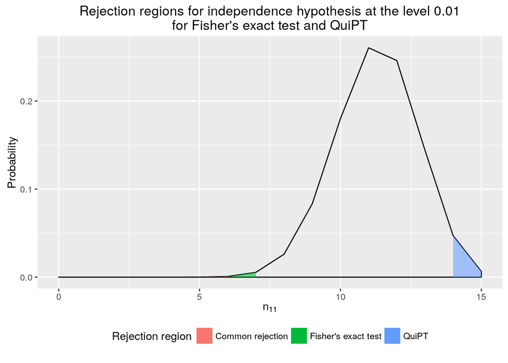

$n=60, n_{1 \bullet}=15, n_{\cdot 1}=45$

### Criteria

#### Information Gain

###### Definition - entropy

For a discrete random variable we define entropy by: $H(X) = - \sum^m p_j log p_j$ For a Bernoulli r.v. we get a simplified expression $H(X) = -p \cdot log(p) - (1-p) \cdot log(1-p)$

###### Definition - conditional entropy

For two discrete r.v. X, Y we define average conditional entropy by: $H(Y|X) = \sum_j P(X=v_j) H(Y|X=v_j)$ If X and Y are Bernoulli’s then: $H(Y|X) = q \cdot H(Y|X=1) + (1-q) \cdot H(Y|X=0)$

###### Definition - Information gain

$IG(Y|X) = H(Y) - H(Y|X)$

#### $\chi^2$